# Reconstrução Filogenética

Luciana Botacim

2025-06-03

### Estudo

Utilizaremos dados provenientes de um banco de dados para a reconstrução da filogenia das espécies em estudo. A análise filogenética é um passo fundamental para a avaliação de padrões de estrutura filogenética, permitindo a investigação de processos ecológicos e evolutivos subjacentes à composição das comunidades.

# Base de dados utilizada

Os dados que utilizaremos foram obtidos no **Repositório de Dados de Estudos Ecológicos CENBAM/PPBio**, vinculado à plataforma **DataONE**.

O estudo selecionado é:

> **Flávia RC Costa. *Composição da Comunidade de Ervas Terrestres da Reserva Ducke*. Programa de Pesquisa em Biodiversidade (PPBio).**

Este conjunto de dados reúne informações sobre a composição de ervas terrestres na **Reserva Florestal Adolpho Ducke**, na Amazônia Central. Ele será nosso modelo pois contém:

- Lista de espécies por unidade amostral Além de:
- Matriz de composição da comunidade
- Metadados

### Dados

1. Site do repositório:  
   👉 https://ppbio.inpa.gov.br/repositorio/dados
2. Clique no botão:  
   **“CLIQUE AQUI PARA ACESSAR OS METADADOS E DADOS PPBIO”**
3. Na página de busca, digite:
   - Título: **Composição da Comunidade de Ervas Terrestres da Reserva Ducke**

O que encontrará:

- **Metadados**: informações descritivas sobre o conjunto de dados, como local de coleta, método amostral, período do estudo, responsáveis, unidades de medida etc.
- **Lista de espécies**: todas as ervas registradas em campo organizadas por parcela
- **Matriz de composição**: abundância de espécies em cada unidade amostral

> 🔹 O passo a passo mencionado anteriormente tem apenas caráter informativo. As matrizes serão fornecidas nas etapas seguintes.

# Prática 1: Correção taxonômica

**Correção taxonômica baseada no projeto REFLORA**

A correção taxonômica consiste na padronização e verificação dos nomes científicos das espécies com base em fontes atualizadas.

O REFLORA, em parceria com o Jardim Botânico do Rio de Janeiro, oferece acesso à Lista de Espécies da Flora do Brasil, que é amplamente utilizada como referência oficial para estudos botânicos e ecológicos no país. A plataforma permite verificar sinônimos, nomes válidos e a classificação taxonômica mais recente, assegurando maior precisão na identificação e análise das espécies. https://floradobrasil.jbrj.gov.br/reflora/listaBrasil/PrincipalUC/PrincipalUC.do

[figure not shown]

Agora vamos aplicar essa correção à **lista de espécies** do banco de dados mencionado anteriormente. O arquivo contém os nomes científicos, os gêneros e as famílias em formato `.csv`.

**Carregue a matriz de espécies**

```r
especie = read.csv(file="species_gen_fam.csv", sep = ";")

head(especie)
```

```
##           scientificname        genero      familia
## 1 Pulchranthus_congestus  Pulchranthus  Acanthaceae
## 2    Nautilocalyx_pictus  Nautilocalyx Gesneriaceae
## 3    Geophila_cordifolia      Geophila    Rubiaceae
## 4    Dracontium_longipes    Dracontium      Araceae
## 5  Dieffenbachia_elegans Dieffenbachia      Araceae
## 6      Bromelia_tubulosa      Bromelia Bromeliaceae
```

**Identifica a estrutura do objeto**

```r
str(especie)
```

```
## 'data.frame':    51 obs. of  3 variables:
##  $ scientificname: chr  "Pulchranthus_congestus" "Nautilocalyx_pictus" "Geophila_cordifolia" "Dracontium_longipes" ...
##  $ genero        : chr  "Pulchranthus" "Nautilocalyx" "Geophila" "Dracontium" ...
##  $ familia       : chr  "Acanthaceae" "Gesneriaceae" "Rubiaceae" "Araceae" ...
```

Indica se é ou não uma tabela de dados (data.frame), número de observações nas linhas e variáveis nas colunas.

**Torna as colunas de um data.frame acessíveis diretamente pelo nome**

```r
attach(especie)
```

**Identificar se é caracter**

```r
class(scientificname)
```

```
## [1] "character"
```

```r
as.character(scientificname)
```

```
##  [1] "Pulchranthus_congestus"    "Nautilocalyx_pictus"
##  [3] "Geophila_cordifolia"       "Dracontium_longipes"
##  [5] "Dieffenbachia_elegans"     "Bromelia_tubulosa"
##  [7] "Disteganthus_Lateralis"    "Pepinia_sprucei"
##  [9] "Costus_arabicus"           "Costus_sprucei"
## [11] "Cyclanthus_bipartitus"     "Calyptrocarya_bicolor"
## [13] "Calyptrocarya_glomerulata" "Calyptrocarya_poeppigiana"
## [15] "Diplasia_karataefolia"     "Hypolytrum_schraderianum"
## [17] "Mapania_sylvatica"         "Pleurostachys_sparsiflora"
## [19] "Scleria_secans"            "Heliconia_acuminata"
## [21] "Heliconia_psittacorum"     "Calathea_altissima"
## [23] "Calathea_cannoides"        "Calathea_mansonis"
## [25] "Calathea_panamensis"       "Ischnosiphon_arouma"
## [27] "Ischnosiphon_gracilis"     "Ischnosiphon_killipii"
## [29] "Ischnosiphon_hirsutus"     "Ischnosiphon_martianus"
## [31] "Ischnosiphon_puberulus"    "Ischnosiphon_verruculosus"
## [33] "Monotagma_tomentosum"      "Monotagma_breviscapum"
## [35] "Monotagma_densiflorum"     "Monotagma_plurispicatum"
## [37] "Monotagma_spicatum"        "Monotagma_vaginatum"
## [39] "Palmorchis_sobralioides"   "Ligeophila_stigmatoptera"
## [41] "Ichnanthus_panicoides"     "Olyra_latifolia"
## [43] "Pariana_campestris"        "Pariana_graciles"
## [45] "Pariana_radiciflora"       "Rapatea_paludosa"
## [47] "Spathanthus_unilateralis"  "Saxofridericia_subcordata"
## [49] "Phenakospermum_guyanense"  "Thurnia_sphaerocephala"
## [51] "Renealmia_floribunda"
```

Utilizaremos a função `get.taxa()` do pacote `flora` para corrigir e padronizar os nomes taxonômicos da nossa lista de espécies.

**Instalar o pacote FLORA** https://cran.r-project.org/web/packages/flora/index.html

`install.packages(flora)`

```r
library(flora)
```

**O pacote flora faz essa correção:**

- A função `get.taxa()` busca os nomes científicos fornecidos na **Lista de Espécies da Flora do Brasil**, por meio da base oficial do projeto **REFLORA**.
- Corrige **sinônimos e nomes inválidos**, retornando os **nomes aceitos** segundo a classificação atual.
- O argumento `as.character(scientificname)` converte o vetor ou coluna `scientificname` para o formato texto, garantindo que os nomes sejam interpretados corretamente pela função.
- O parâmetro `life.form = TRUE` indica que **será retornada** a informação sobre a forma de vida das espécies (como erva, arbusto, árvore etc).
- Se esse argumento fosse `life.form = FALSE`, o resultado não incluiria essas informações adicionais.

```r
names = get.taxa(as.character(scientificname), life.form = T)
head(names)
```

```
##      id                             scientific.name accepted.name       family
## 1 79882    Pulchranthus congestus (Lindau) V.M.Baum          <NA>  Acanthaceae
## 2 84051         Nautilocalyx pictus (Hook.) Sprague          <NA> Gesneriaceae
## 3 24465                    Geophila cordifolia Miq.          <NA>    Rubiaceae
## 4 21996                   Dracontium longipes Engl.          <NA>      Araceae
## 5 33836 Dieffenbachia elegans A.M.E.Jonker & Jonker          <NA>      Araceae
## 6 34289                   Bromelia tubulosa L.B.Sm.          <NA> Bromeliaceae
##   taxon.rank taxon.status             search.str threat.status          notes
## 1    species     accepted Pulchranthus congestus          <NA> was misspelled
## 2    species     accepted    Nautilocalyx pictus          <NA> was misspelled
## 3    species     accepted    Geophila cordifolia          <NA> was misspelled
## 4    species     accepted    Dracontium longipes          <NA> was misspelled
## 5    species     accepted  Dieffenbachia elegans          <NA> was misspelled
## 6    species     accepted      Bromelia tubulosa          <NA> was misspelled
##          original.search life.form
## 1 Pulchranthus_congestus      Erva
## 2    Nautilocalyx_pictus      Erva
## 3    Geophila_cordifolia      Erva
## 4    Dracontium_longipes      Erva
## 5  Dieffenbachia_elegans      Erva
## 6      Bromelia_tubulosa      Erva
```

A função `get.taxa()` do pacote `flora` retorna um data frame com colunas como: `id`, `scientific.name`, `accepted.name`, `family`, `taxon.rank`, `taxon.status`, `search.str`, `threat.status`, `notes`, `original.search` e `life.form`.

**Salvar a matriz de correção**

```r
write.table(names, file = "flora_gen_fam.csv", sep = ";")
```

# Prática 2: Reconstrução Filogenética

**Organização da matriz de espécies (fora do R**)

Antes de importar os dados para o R, precisamos organizar a **matriz de espécies** corretamente:

- O pacote `V.PhyloMaker` só reconhece nomes científicos **com gênero e epíteto separados por um underline** (`_`).

  ✅ Exemplo de formato correto: `Copaifera_langsdorffii`
- Edite a lista de espécies, no Excel, e garanta que todos os nomes estejam nesse formato, **sem autores, acentos ou abreviações**.
- Salve o arquivo no formato `.csv`.

Para a reconstrução filogenética, utiliza-se a coluna `accepted.name` da lista que corrigimos anteriormente, além de colunas separadas para `gênero` e `família`. É recomendável também incluir duas colunas em branco, com os títulos `genus.GBOTB` e `spp.GBOTB`.

**Instalar o pacote V.PhyloMaker2**

O pacote `V.PhyloMaker2` não está disponível no CRAN, por isso precisamos instalá-lo diretamente a partir do GitHub. Para isso, utilizamos a função `install_github()` do pacote `devtools`.

`install.packages(devtools)`

`library("devtools")`

`devtools::install_github("jinyizju/V.PhyloMaker2")`

Outros pacotes também serão necessários para ler e salvar a filogenia.

`install.packages(picante)`

`install.packages(phytools)`

```r
library(V.PhyloMaker2)
library(picante)
library(phytools)
```

**Carregar a matriz para, em seguida, reconsrtuir a filogenia.**

```r
phylo  <-  read.csv("lista_phylo.csv", sep = ";")
head(phylo)
```

```
##           scientificname        genero      familia genus.GBOTB spp.GBOTB
## 1 Pulchranthus_congestus  Pulchranthus  Acanthaceae          NA        NA
## 2    Nautilocalyx_pictus  Nautilocalyx Gesneriaceae          NA        NA
## 3    Geophila_cordifolia      Geophila    Rubiaceae          NA        NA
## 4    Dracontium_longipes    Dracontium      Araceae          NA        NA
## 5  Dieffenbachia_elegans Dieffenbachia      Araceae          NA        NA
## 6      Bromelia_tubulosa      Bromelia Bromeliaceae          NA        NA
```

```r
tree <- phylo.maker(sp.list = phylo,  tree = GBOTB.extended.TPL,
                      nodes = nodes.info.1.TPL, scenarios="S3")
```

**Salvar a árvore reconstruída no formato .tre**

```r
write.tree(tree$scenario.3, "phylo_tree.tre")
```

**Carregar a visualizar a árvore**

```r
plot_tree <- read.tree("phylo_tree.tre")
plot_tree
```

```
##
## Phylogenetic tree with 48 tips and 37 internal nodes.
##
## Tip labels:
##   Pulchranthus_congestus, Nautilocalyx_pictus, Geophila_cordifolia, Aspidogyne_stigmatoptera, Palmorchis_sobralioides, Ichnanthus_panicoides, ...
## Node labels:
##   mrcaott2ott121, mrcaott248ott1191, , mrcaott121ott290, mrcaott121ott2256, mrcaott121ott334, ...
##
## Rooted; includes branch length(s).
```

```r
plot_tree$tip.label
```

```
##  [1] "Pulchranthus_congestus"    "Nautilocalyx_pictus"
##  [3] "Geophila_cordifolia"       "Aspidogyne_stigmatoptera"
##  [5] "Palmorchis_sobralioides"   "Ichnanthus_panicoides"
##  [7] "Olyra_latifolia"           "Pariana_campestris"
##  [9] "Pariana_radiciflora"       "Pleurostachys_sparsiflora"
## [11] "Calyptrocarya_poeppigiana" "Calyptrocarya_glomerulata"
## [13] "Calyptrocarya_bicolor"     "Scleria_secans"
## [15] "Mapania_sylvatica"         "Hypolytrum_schraderianum"
## [17] "Diplasia_karatifolia"      "Thurnia_sphaerocephala"
## [19] "Saxofridericia_aculeata"   "Rapatea_paludosa"
## [21] "Spathanthus_unilateralis"  "Bromelia_tubulosa"
## [23] "Pitcairnia_sprucei"        "Renealmia_floribunda"
## [25] "Costus_sprucei"            "Costus_arabicus"
## [27] "Ischnosiphon_martianus"    "Ischnosiphon_killipii"
## [29] "Ischnosiphon_gracilis"     "Ischnosiphon_arouma"
## [31] "Ischnosiphon_hirsutus"     "Ischnosiphon_puberulus"
## [33] "Goeppertia_panamensis"     "Goeppertia_mansonis"
## [35] "Goeppertia_cannoides"      "Goeppertia_altissima"
## [37] "Monotagma_vaginatum"       "Monotagma_spicatum"
## [39] "Monotagma_plurispicatum"   "Monotagma_breviscapum"
## [41] "Monotagma_densiflorum"     "Monotagma_tomentosum"
## [43] "Phenakospermum_guyannense" "Heliconia_acuminata"
## [45] "Heliconia_psittacorum"     "Cyclanthus_bipartitus"
## [47] "Dieffenbachia_elegans"     "Dracontium_longipes"
```

```r
class(plot_tree)
```

```
## [1] "phylo"
```

`class` retorna a classe do objeto.

**Salvar a árvore reconstruída no formato .jpg**

```r
jpeg("plot_tree.jpg", width=16, height=16, unit="cm", res=300)
```

**Visualizar a árvore adicionando a escala**

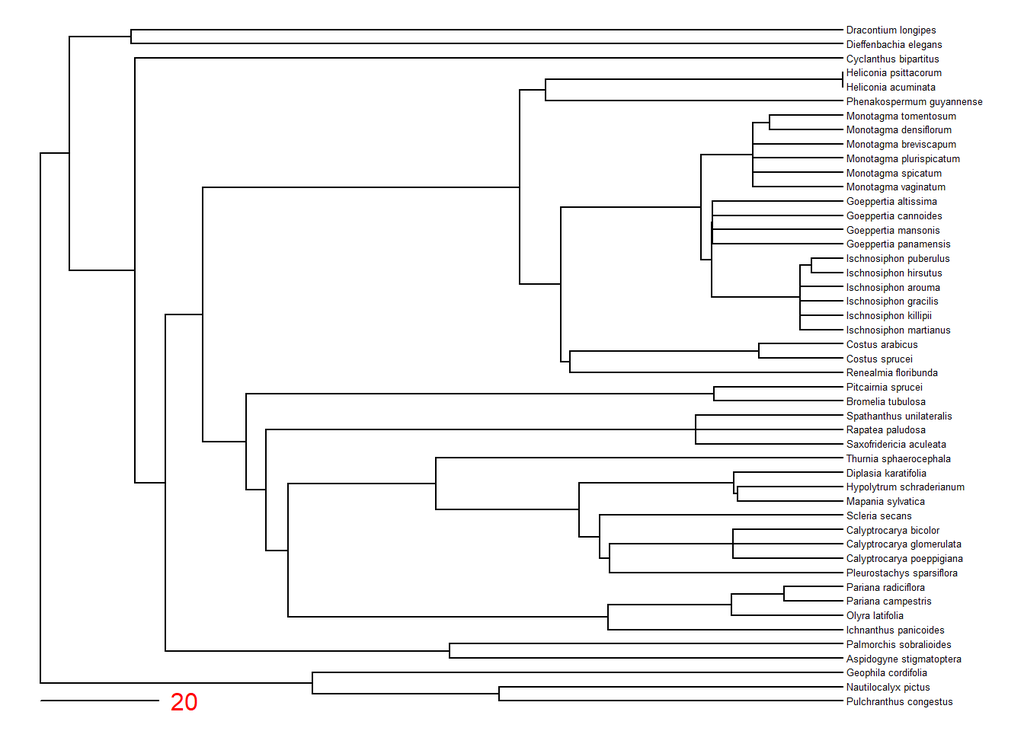

```r
plotTree(plot_tree, fsize=0.4, type="phylogram", lwd=1)
add.scale.bar(cex = 1, font = 1, col = "red")
```